# NLP Australian legal case data

- Legal documents are generally written in complex legal language. Often, these documents are hard to understand, especially when it comes to contracts, piece of legislation and court records. Interpretation into Plain English and creation of summaries for lengthy documents require a lot of time and money. Law firms hire a large number of support employees to perform these types of tasks. One way to minimize the effort and cost is developing NLP in Machine learning algorithm, which creates summaries of legal texts using topic modeling techniques knows as Latent Dirichlet Allocation(LDA).
- The dataset contains Australian legal around 4000 cases from the Federal Court of Australia (FCA) for the year 2006,2007,2008 and 2009. This data was accessed from UCI machine learning repository.

```python
# import library

import codecs as codecs
from bs4 import BeautifulSoup
import pandas as pd
import glob
import re
import datefinder
import pickle


import numpy as np
import pandas as pd
import matplotlib.pyplot as plt
import seaborn as sns


import nltk
from nltk import wordpunct_tokenize
from nltk.corpus import stopwords
from wordcloud import WordCloud,STOPWORDS
from nltk.stem.wordnet import WordNetLemmatizer
from sklearn.feature_extraction.text import TfidfVectorizer, CountVectorizer
from sklearn.decomposition import NMF, LatentDirichletAllocation
import string
import textblob as tb
import spacy


import gensim
from gensim.models import Phrases
from gensim.models import CoherenceModel
from gensim import corpora, models, similarities
from gensim.utils import simple_preprocess



# Plotting tools
import pyLDAvis
import pyLDAvis.gensim
%matplotlib inline

# Enable logging for gensim - optional
import logging
logging.basicConfig(format='%(asctime)s : %(levelname)s : %(message)s', level=logging.ERROR)

import warnings
warnings.filterwarnings("ignore",category=DeprecationWarning)
```

# Parsing XML file to dataframe

- The data consists of around 4000 separate XML files of individual legal cases.
- First step is parsing these files to convert them into pandas data frame for further use.

```python
# function to short files base on numerical number from the folder
numbers = re.compile(r'(\d+)')
def numericalSort(value):
    parts = numbers.split(value)
    parts[1::2] = map(int, parts[1::2])
    return parts
```

```python
# convert XML files into pandas dataframe

file_path="/Users/akshay/Downloads/ADP_challange/corpus-2/fulltext/*.xml"
files=sorted(glob.glob(file_path),key=numericalSort)
lst=[]
rows = []
df_cols = ["name", "link", "catchphrases", "sentences"]


def xml_dataframe(xml_files):
    for ind,file in enumerate(xml_files):
        # read xml files
        with open(file, "r",encoding="utf8", errors='ignore') as file:
            soup = BeautifulSoup(file, "html.parser",exclude_encodings='0xe9')
            # extract name
            name=soup.find('name')
            s_name=name.get_text(' ',strip=False)

            # extract website link
            link=soup.find('austlii')
            s_link=link.get_text(',',strip=True)

            # extract catchphrases
            catchphrases=soup.find('catchphrases')
            s_catch=catchphrases.get_text(',',strip=True)

            # extract sentences
            sentences=soup.find('sentences')
            s_sent=sentences.get_text(',',strip=True)

    # create dictionary for name, aystlii, catchphrases and sentence and append in the list
        rows.append({"name": s_name, "link": s_link,"catchphrases": s_catch, "sentences": s_sent})
        #rows.append({"name": s_name, "link": s_link,"catchphrases": s_catch})


    out_df = pd.DataFrame(rows, columns = df_cols)

    return out_df
```

```python
df=xml_dataframe(files)
```

```python
df.head()
```

|  | name | link | catchphrases | sentences |
| --- | --- | --- | --- | --- |
| 0 | Sharman Networks Ltd v Universal Music Austral... | http://www.austlii.edu.au/au/cases/cth/FCA/200... | application for leave to appeal,authorisation ... | Background to the current application\n\n1 The... |
| 1 | SZAIX v Minister for Immigration & Multicultur... | http://www.austlii.edu.au/au/cases/cth/FCA/200... | appeal,points not taken below,when allowed to ... | Introduction \n \n1 This is an appeal from a j... |
| 2 | QAAI v Minister for Immigration and Multicultu... | http://www.austlii.edu.au/au/cases/cth/FCA/200... | judicial review,protection visa,refugee review... | BACKGROUND \n The Background Application \n \n... |
| 3 | Comcare v Christina Foster [2006] FCA 6 (12 Ja... | http://www.austlii.edu.au/au/cases/cth/FCA/200... | application pursuant to section 44 of the admi... | THE APPLICATION \n \n 1 This is an application... |
| 4 | Communications, Electrical, Electronic, Energy... | http://www.austlii.edu.au/au/cases/cth/FCA/200... | penalty,freedom of association,contravention o... | 1 On 18 November 2005 I published reasons for ... |

# Data cleaning and text preprocessing

### Tokenization, Lemmatization and Stopwords handling

##### Text data is converted into a machine readable format to develop machine learning solution:

- removing sentences related to case owners info, filing, decisions dates, etc
- keeping words that start with letters and removing non-letter words and characters
- removing extra spaces
- converting all characters to lower case and splitting words
- lemmatization to remove suffix of words but keeping meaning of the original word

```python
# function for text preprocessing
wl = WordNetLemmatizer()  # bettwer way to remove suffix by keping meaning of the full words

def text_processing(row):
    review = row.partition('Associate:')[0] # remove endings of sentences after 'Associate:' which contain only information regarding dates and companies/person involved in the case
    review = re.sub('[^a-zA-Z]', ' ', row) # match all strings that start with a letter, the second means match all strings that contain a non-letter
    review = re.sub(r'(?:^| )\w(?:$| )', ' ', review) # remove other characters and numbers from the string
    review = re.sub(' +', ' ', review) # remove extra spaces from string
    review = review.lower() # lower case
    review = review.split() # split words
    #wl = WordNetLemmatizer()  # bettwer way to remove suffix but keping meaning of the full words
    review = [wl.lemmatize(word) for word in review if not word in set(stopwords.words('english'))] # remove most common english stop words such as a,an, the in ,on etc
    review = ' '.join(review)
    return review
```

```python
# save file for easy excess
#df1=df.copy()
#df1['sentence_process']=df1.sentences.apply(text_processing)
#df1.to_csv('data_sample500_legal.csv')
df1=pd.read_csv('data_sample500_legal.csv')
```

```python
df1.head()
```

|  | Unnamed: 0 | name | link | catchphrases | sentences | sentence_process |
| --- | --- | --- | --- | --- | --- | --- |
| 0 | 0 | Sharman Networks Ltd v Universal Music Austral... | http://www.austlii.edu.au/au/cases/cth/FCA/200... | application for leave to appeal,authorisation ... | Background to the current application\n\n1 The... | background current application applicant sharm... |
| 1 | 1 | SZAIX v Minister for Immigration & Multicultur... | http://www.austlii.edu.au/au/cases/cth/FCA/200... | appeal,points not taken below,when allowed to ... | Introduction \n \n1 This is an appeal from a j... | introduction appeal judgment federal magistrat... |
| 2 | 2 | QAAI v Minister for Immigration and Multicultu... | http://www.austlii.edu.au/au/cases/cth/FCA/200... | judicial review,protection visa,refugee review... | BACKGROUND \n The Background Application \n \n... | background background application application ... |
| 3 | 3 | Comcare v Christina Foster [2006] FCA 6 (12 Ja... | http://www.austlii.edu.au/au/cases/cth/FCA/200... | application pursuant to section 44 of the admi... | THE APPLICATION \n \n 1 This is an application... | application application original jurisdiction ... |
| 4 | 4 | Communications, Electrical, Electronic, Energy... | http://www.austlii.edu.au/au/cases/cth/FCA/200... | penalty,freedom of association,contravention o... | 1 On 18 November 2005 I published reasons for ... | november published reason judgment proceeding ... |

# Topic modelling for Legal documents

- Topic modeling is statistical modeling for finding topics that occur in the collection of documents.
- LDA’s approach to topic modeling is considering each document as a collection of topics in a certain proportion, while each topic as a collection of keywords, again, in a certain proportion.
- LDA builds topic per document model and words per topic model, modelled as Dirichlet distributions.
- LDA rearranges topic distribution within the document and keyword distribution within each topic to obtain a good composition of topic-keywords Dirichlet distribution.
- Topics Modelling would identify different topics in legal documents, which could be next summarized.
- gensim library for NLP is used to impliment LDA.
- text from 'sentences' column is transformed into LDA compatible format

## LDA with gensim

### n-gram and dictionary of words with index

- split the text and generate the n-gram ( unigram, bigram, tri-gram and so on )
- create a dictionary from the data using gensim corpora ( every term assigned as index )
- we keep first 100000 most frequent tokens
- filter out terms, which occur in less than 15 articles and more then 70% of the articles

```python
# function to generate n-gram
n=1
def n_gram(row):
    ngrm = nltk.ngrams(row,n) # bigram # monogram
    blst = list(ngrm)
    text = ' '.join(['_'.join(i)for i in blst])
    text=text.split()
    return text
```

```python
# transform dataframe into required format
df1['sentence_process_list'] = df1['sentence_process'].apply(lambda x: x.split())
df1['sentence_process_ngram'] = df1.sentence_process_list.apply(n_gram)

# Creating the term dictionary of our corpus, where each unique term is assigned an index.
dictionary = corpora.Dictionary(df1.sentence_process_ngram)
#keep only the first 100000 most frequent tokens. Filter out terms which occur in less than 15 articles & more than 70% of the articles
dictionary.filter_extremes(no_below=15, no_above=0.7, keep_n=100000) # tune for better result
```

### LDA model with Bag of Words(BOW)

```python
# creating bag of words corpus and LDA model
# requesting LDA to find 10 topics in the data:
# creating the object for LDA model using gensim library

bow_corpus = [dictionary.doc2bow(doc) for doc in df1.sentence_process_ngram]
NUM_TOPICS = 10
# BOG LDA model
ldamodel = gensim.models.ldamodel.LdaModel(bow_corpus, num_topics = NUM_TOPICS, id2word=dictionary, passes=15)
# using this model for cluster plots, just parametrise number of topics here so it would easy to plot directly
lda_model = gensim.models.ldamodel.LdaModel(corpus=bow_corpus,
                                           id2word=dictionary,
                                           num_topics=10,
                                           random_state=100,
                                           update_every=1,
                                           chunksize=20,
                                           passes=10,
                                           alpha='symmetric',
                                           iterations=100,
                                           minimum_probability=0.005,
                                           per_word_topics=True)
ldamodel.save('model5.gensim')
model =  models.LdaModel.load('model5.gensim')
```

```python
topics = ldamodel.print_topics(num_words=10)
for topic in topics:
    print(topic)
```

```
(0, '0.012*"scheme" + 0.011*"share" + 0.011*"company" + 0.011*"agreement" + 0.009*"interest" + 0.007*"meeting" + 0.007*"property" + 0.007*"member" + 0.006*"director" + 0.006*"trust"')
(1, '0.025*"company" + 0.014*"defendant" + 0.013*"ltd" + 0.013*"plaintiff" + 0.012*"pty" + 0.010*"creditor" + 0.009*"liquidator" + 0.007*"corporation" + 0.007*"debt" + 0.007*"administrator"')
(2, '0.014*"dr" + 0.009*"patent" + 0.006*"design" + 0.004*"work" + 0.004*"cross" + 0.004*"ltd" + 0.004*"m" + 0.004*"use" + 0.004*"university" + 0.004*"gray"')
(3, '0.017*"commissioner" + 0.015*"tax" + 0.015*"income" + 0.015*"mark" + 0.011*"trade" + 0.010*"year" + 0.008*"assessment" + 0.008*"good" + 0.007*"taxpayer" + 0.007*"business"')
(4, '0.013*"document" + 0.007*"power" + 0.005*"legal" + 0.005*"ltd" + 0.005*"section" + 0.005*"conduct" + 0.005*"action" + 0.004*"statement" + 0.004*"rule" + 0.004*"information"')
(5, '0.009*"right" + 0.009*"title" + 0.009*"employee" + 0.008*"area" + 0.008*"native" + 0.008*"work" + 0.007*"land" + 0.006*"group" + 0.006*"union" + 0.006*"member"')
(6, '0.056*"tribunal" + 0.035*"appellant" + 0.014*"minister" + 0.011*"review" + 0.010*"appeal" + 0.010*"visa" + 0.009*"magistrate" + 0.008*"information" + 0.007*"finding" + 0.007*"error"')
(7, '0.017*"m" + 0.014*"appeal" + 0.007*"leave" + 0.006*"affidavit" + 0.006*"honour" + 0.006*"filed" + 0.006*"bankruptcy" + 0.005*"trustee" + 0.005*"rule" + 0.005*"pay"')
(8, '0.012*"right" + 0.010*"seven" + 0.010*"foxtel" + 0.009*"optus" + 0.009*"pay" + 0.008*"licence" + 0.008*"market" + 0.008*"offer" + 0.008*"television" + 0.007*"telstra"')
(9, '0.011*"agreement" + 0.008*"contract" + 0.007*"conduct" + 0.007*"price" + 0.006*"service" + 0.006*"product" + 0.005*"business" + 0.005*"accc" + 0.005*"representation" + 0.005*"sale"')
```

#### LDA performance criteria

- Unsupervised LDA model is checked based on its perplexity and coherence score. Lower perplexity and higher coherence scores are better.

```python
# LDA model performance criteria
# Compute Perplexity (a measure of how good the model is. lower the better.)
print(ldamodel.log_perplexity(bow_corpus))
# Compute Coherence Score
coherence_model_lda = CoherenceModel(model=ldamodel, texts=df1.sentence_process_ngram, dictionary=dictionary, coherence='c_v')
coherence_lda = coherence_model_lda.get_coherence()
print('\nCoherence Score: ', coherence_lda)
```

```
-7.714037476609097

Coherence Score:  0.5264702100669194
```

### LDA using TF-IDF

- BOW corpus is converted into TFIDF using gensim model package

```python
# TFIDF corpus

tfidf = models.TfidfModel(bow_corpus)
tfidf_corpus = tfidf[bow_corpus]

# TFIDF LDA model
lda_model_tfidf = gensim.models.LdaMulticore(tfidf_corpus, num_topics=10, id2word=dictionary, passes=2)
```

```python
for idx, topic in lda_model_tfidf.print_topics(num_words=30):
    print('Topic: {} Word: {}'.format(idx, topic))
```

```
Topic: 0 Word: 0.003*"tribunal" + 0.003*"appellant" + 0.001*"motion" + 0.001*"magistrate" + 0.001*"plaintiff" + 0.001*"awb" + 0.001*"appeal" + 0.001*"document" + 0.001*"product" + 0.001*"defendant" + 0.001*"privilege" + 0.001*"agreement" + 0.001*"dr" + 0.001*"minister" + 0.001*"company" + 0.001*"des…
Topic: 1 Word: 0.012*"tribunal" + 0.011*"appellant" + 0.005*"magistrate" + 0.003*"visa" + 0.003*"minister" + 0.003*"appeal" + 0.002*"review" + 0.002*"immigration" + 0.002*"persecution" + 0.002*"migration" + 0.002*"refugee" + 0.002*"error" + 0.002*"rrt" + 0.002*"fear" + 0.002*"delegate" + 0.002*"mult…
Topic: 2 Word: 0.007*"tribunal" + 0.006*"appellant" + 0.002*"visa" + 0.002*"magistrate" + 0.001*"appeal" + 0.001*"minister" + 0.001*"review" + 0.001*"dr" + 0.001*"scheme" + 0.001*"company" + 0.001*"medical" + 0.001*"security" + 0.001*"m" + 0.001*"defendant" + 0.001*"member" + 0.001*"asic" + 0.001*"c…
Topic: 3 Word: 0.006*"tribunal" + 0.005*"appellant" + 0.002*"magistrate" + 0.002*"bankruptcy" + 0.002*"minister" + 0.002*"appeal" + 0.002*"asic" + 0.001*"defendant" + 0.001*"meeting" + 0.001*"m" + 0.001*"share" + 0.001*"scheme" + 0.001*"trustee" + 0.001*"motion" + 0.001*"visa" + 0.001*"company" + 0.…
Topic: 4 Word: 0.002*"penalty" + 0.002*"tribunal" + 0.002*"commissioner" + 0.002*"company" + 0.002*"tax" + 0.002*"scheme" + 0.001*"appellant" + 0.001*"agreement" + 0.001*"income" + 0.001*"discovery" + 0.001*"liquidator" + 0.001*"taxpayer" + 0.001*"document" + 0.001*"creditor" + 0.001*"contract" + 0.…
Topic: 5 Word: 0.005*"tribunal" + 0.004*"appellant" + 0.002*"patent" + 0.002*"magistrate" + 0.002*"appeal" + 0.002*"visa" + 0.001*"minister" + 0.001*"plaintiff" + 0.001*"siminton" + 0.001*"defendant" + 0.001*"motion" + 0.001*"dr" + 0.001*"mark" + 0.001*"m" + 0.001*"cross" + 0.001*"design" + 0.001*"l…
Topic: 6 Word: 0.008*"tribunal" + 0.008*"appellant" + 0.003*"magistrate" + 0.003*"falun" + 0.003*"visa" + 0.003*"gong" + 0.002*"rrt" + 0.002*"appeal" + 0.002*"minister" + 0.002*"china" + 0.001*"immigration" + 0.001*"persecution" + 0.001*"review" + 0.001*"creditor" + 0.001*"multicultural" + 0.001*"mi…
Topic: 7 Word: 0.006*"native" + 0.004*"title" + 0.003*"land" + 0.002*"creditor" + 0.002*"tribunal" + 0.002*"company" + 0.002*"liquidator" + 0.002*"patent" + 0.002*"administrator" + 0.002*"area" + 0.002*"agreement" + 0.001*"commissioner" + 0.001*"group" + 0.001*"scheme" + 0.001*"income" + 0.001*"wind…
Topic: 8 Word: 0.007*"tribunal" + 0.005*"appellant" + 0.002*"magistrate" + 0.002*"minister" + 0.001*"visa" + 0.001*"appeal" + 0.001*"bangladesh" + 0.001*"immigration" + 0.001*"review" + 0.001*"persecution" + 0.001*"defendant" + 0.001*"patent" + 0.001*"error" + 0.001*"scheme" + 0.001*"company" + 0.00…
Topic: 9 Word: 0.002*"tribunal" + 0.002*"appellant" + 0.002*"defendant" + 0.002*"company" + 0.001*"plaintiff" + 0.001*"price" + 0.001*"creditor" + 0.001*"liquidator" + 0.001*"accc" + 0.001*"agreement" + 0.001*"lease" + 0.001*"asic" + 0.001*"garrett" + 0.001*"sale" + 0.001*"magistrate" + 0.001*"deed"…
```

#### TF-IDF LDA model performace

```python
# Compute Perplexity (a measure of how good the model is. lower the better.)
print(ldamodel.log_perplexity(tfidf_corpus))
# Compute Coherence Score
coherence_model_lda = CoherenceModel(model=lda_model_tfidf, texts=df1.sentence_process_ngram, dictionary=dictionary, coherence='c_v')
coherence_lda = coherence_model_lda.get_coherence()
print('\nCoherence Score: ', coherence_lda)
```

```
-15.352586445059432

Coherence Score:  0.33367187069222626
```

## Dominant topics and percentage contribution to each topics

- using LDA with tfidf embedding
- dominant topics are identified based on their percentage contribution and relevancy of keywords for each documents

```python
data = df1.sentences.values.tolist()

def format_topics_sentences(ldamodel=None, corpus=tfidf_corpus, texts=data):
    # Init output
    sent_topics_df = pd.DataFrame()

    # Get main topic in each document
    for i, row_list in enumerate(ldamodel[corpus]):
        row = row_list[0] if ldamodel.per_word_topics else row_list
        # print(row)
        row = sorted(row, key=lambda x: (x[1]), reverse=True)
        # Get the Dominant topic, Percentage Contribution and Keywords for each document
        for j, (topic_num, prop_topic) in enumerate(row):
            if j == 0:  # => dominant topic
                wp = ldamodel.show_topic(topic_num)
                topic_keywords = ", ".join([word for word, prop in wp])
                sent_topics_df = sent_topics_df.append(pd.Series([int(topic_num), round(prop_topic,4), topic_keywords]), ignore_index=True)
            else:
                break
    sent_topics_df.columns = ['Dominant_Topic', 'Perc_Contribution', 'Topic_Keywords']

    # Add original text to the end of the output
    contents = pd.Series(texts)
    sent_topics_df = pd.concat([sent_topics_df, contents], axis=1)
    return(sent_topics_df)
```

```python
df_topic_sents_keywords = format_topics_sentences(ldamodel=lda_model_tfidf, corpus=tfidf_corpus, texts=df1['sentence_process_ngram'])

# Format
df_dominant_topic = df_topic_sents_keywords.reset_index()
df_dominant_topic.columns = ['Document_No', 'Dominant_Topic', 'Topic_Perc_Contrib', 'Keywords', 'Text']
df_dominant_topic.head(10)
```

|  | Document_No | Dominant_Topic | Topic_Perc_Contrib | Keywords | Text |
| --- | --- | --- | --- | --- | --- |
| 0 | 0 | 5.0 | 0.6159 | tribunal, appellant, patent, magistrate, appea... | [background, current, application, applicant, ... |
| 1 | 1 | 1.0 | 0.9405 | tribunal, appellant, magistrate, visa, ministe... | [introduction, appeal, judgment, federal, magi... |
| 2 | 2 | 1.0 | 0.7707 | tribunal, appellant, magistrate, visa, ministe... | [background, background, application, applicat... |
| 3 | 3 | 3.0 | 0.5457 | tribunal, appellant, magistrate, bankruptcy, m... | [application, application, original, jurisdict... |
| 4 | 4 | 4.0 | 0.9164 | penalty, tribunal, commissioner, company, tax,... | [november, published, reason, judgment, procee... |
| 5 | 5 | 3.0 | 0.7551 | tribunal, appellant, magistrate, bankruptcy, m... | [circumstance, applicant, present, dispute, na... |
| 6 | 6 | 1.0 | 0.6355 | tribunal, appellant, magistrate, visa, ministe... | [edmonds, introduction, appeal, pursuant, admi... |
| 7 | 7 | 4.0 | 0.9286 | penalty, tribunal, commissioner, company, tax,... | [nature, proceeding, principal, issue, proceed... |
| 8 | 8 | 1.0 | 0.5613 | tribunal, appellant, magistrate, visa, ministe... | [circumstance, revealed, application, prelimin... |
| 9 | 9 | 2.0 | 0.5014 | tribunal, appellant, visa, magistrate, appeal,... | [application, interlocutory, relief, form, man... |

## Most representative sentences

```python
# Display setting to show more characters in column
pd.options.display.max_colwidth = 100

sent_topics_sorteddf_mallet = pd.DataFrame()
sent_topics_outdf_grpd = df_topic_sents_keywords.groupby('Dominant_Topic')

for i, grp in sent_topics_outdf_grpd:
    sent_topics_sorteddf_mallet = pd.concat([sent_topics_sorteddf_mallet,
                                             grp.sort_values(['Perc_Contribution'], ascending=False).head(1)],
                                            axis=0)

# Reset Index
sent_topics_sorteddf_mallet.reset_index(drop=True, inplace=True)

# Format
sent_topics_sorteddf_mallet.columns = ['Topic_Num', "Topic_Perc_Contrib", "Keywords", "Representative Text"]

# Show
sent_topics_sorteddf_mallet.head(10)
```

|  | Topic_Num | Topic_Perc_Contrib | Keywords | Representative Text |
| --- | --- | --- | --- | --- |
| 0 | 0.0 | 0.9333 | tribunal, appellant, motion, magistrate, plaintiff, awb, appeal, document, product, defendant | [proceeding, commenced, application, filed, july, amended, application, filed, july, amended, ap... |
| 1 | 1.0 | 0.9546 | tribunal, appellant, magistrate, visa, minister, appeal, review, immigration, persecution, migra... | [appeal, judgment, federal, magistrate, delivered, february, dismissing, application, judicial, ... |
| 2 | 2.0 | 0.9334 | tribunal, appellant, visa, magistrate, appeal, minister, review, dr, scheme, company | [introduction, krueger, transport, equipment, pty, ltd, krueger, designing, building, trailer, a... |
| 3 | 3.0 | 0.9535 | tribunal, appellant, magistrate, bankruptcy, minister, appeal, asic, defendant, meeting, m | [introduction, application, applicant, ntd, disqualify, involvement, proceeding, particular, hea... |
| 4 | 4.0 | 0.9421 | penalty, tribunal, commissioner, company, tax, scheme, appellant, agreement, income, discovery | [background, applicant, bhpb, freight, pty, ltd, bhpb, disponent, owner, motor, vessel, global, ... |
| 5 | 5.0 | 0.9397 | tribunal, appellant, patent, magistrate, appeal, visa, minister, plaintiff, siminton, defendant | [judgment, liability, handed, april, black, decker, inc, gmca, pty, ltd, fca, subsequently, hear... |
| 6 | 6.0 | 0.9259 | tribunal, appellant, magistrate, falun, visa, gong, rrt, appeal, minister, china | [introduction, june, article, appeared, sunday, telegraph, newspaper, new, south, wale, sunday, ... |
| 7 | 7.0 | 0.9481 | native, title, land, creditor, tribunal, company, liquidator, patent, administrator, area | [introduction, timber, creek, small, township, north, western, corner, northern, territory, lie,... |
| 8 | 8.0 | 0.4443 | tribunal, appellant, magistrate, minister, visa, appeal, bangladesh, immigration, review, persec... | [introduction, genrx, pty, limited, genrx, since, changed, name, apotex, pty, ltd, applied, cour... |
| 9 | 9.0 | 0.8978 | tribunal, appellant, defendant, company, plaintiff, price, creditor, liquidator, accc, agreement | [australian, competition, consumer, commission, global, prepaid, communication, pty, ltd, acn, i... |

### Frequency distribution of word counts

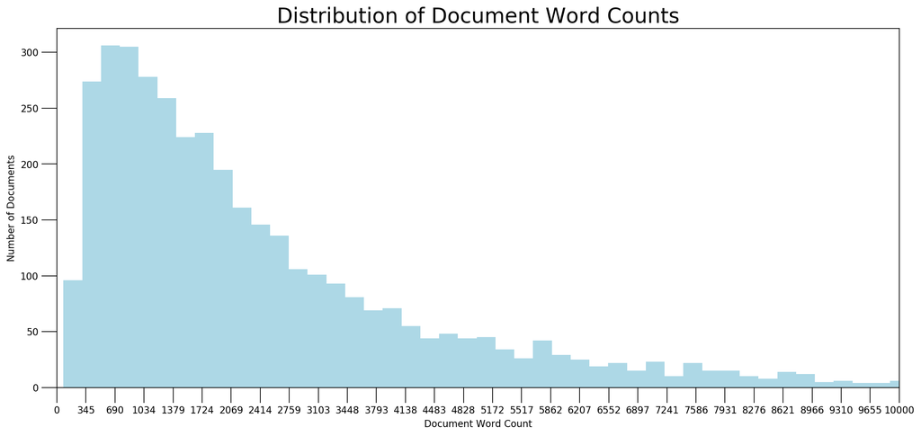

```python
doc_lens = [len(d) for d in df_dominant_topic.Text]
# Plot
plt.figure(figsize=(16,7), dpi=160)
plt.hist(doc_lens, bins = 1000, color='lightblue')
plt.gca().set(xlim=(0, 10000), ylabel='Number of Documents', xlabel='Document Word Count')
plt.tick_params(size=16)
plt.xticks(np.linspace(0,10000,30))
plt.title('Distribution of Document Word Counts', fontdict=dict(size=22))
plt.show()
```

### Word cloud of top N worlds in each topics

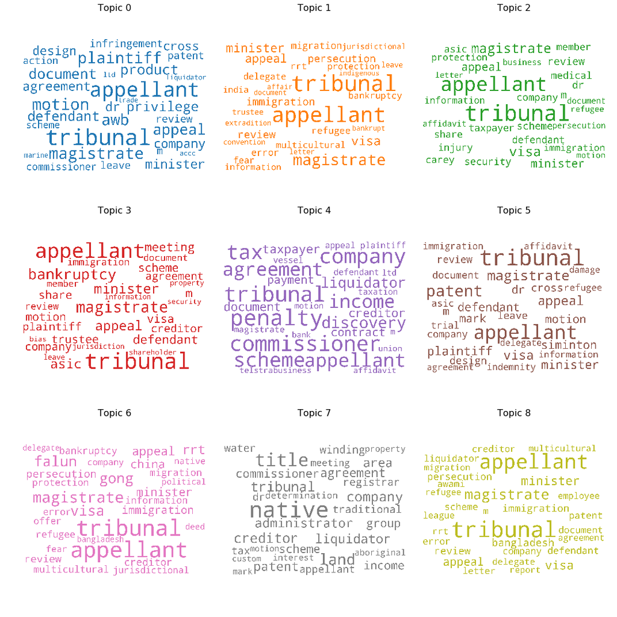

```python
# 1. Wordcloud of Top N words in each topic
from matplotlib import pyplot as plt
from wordcloud import WordCloud, STOPWORDS
import matplotlib.colors as mcolors

cols = [color for name, color in mcolors.TABLEAU_COLORS.items()]  # more colors: 'mcolors.XKCD_COLORS'
stop_words = stopwords.words('english')
cloud = WordCloud(stopwords=stop_words,
                  background_color='white',
                  width=2500,
                  height=1800,
                  max_words=35,
                  colormap='tab10',
                  color_func=lambda *args, **kwargs: cols[i],
                  prefer_horizontal=1.0)

topics = lda_model_tfidf.show_topics(num_topics=10, num_words=30,formatted=False)

fig, axes = plt.subplots(3, 3, figsize=(15,15), sharex=True, sharey=True)

for i, ax in enumerate(axes.flatten()):
    fig.add_subplot(ax)
    topic_words = dict(topics[i][1])
    cloud.generate_from_frequencies(topic_words, max_font_size=300)
    plt.gca().imshow(cloud)
    plt.gca().set_title('Topic ' + str(i), fontdict=dict(size=16))
    plt.gca().axis('off')


plt.subplots_adjust(wspace=0, hspace=0)
plt.axis('off')
plt.margins(x=0, y=0)
plt.tight_layout()
plt.show()

figure = ax.get_figure()
figure.savefig('image/topworlds_eachtopics.png',bbox_inches = 'tight')
```

### Word counts and importance

[figure not shown]

```python
from collections import Counter
topics = lda_model_tfidf.show_topics(formatted=False)
data_flat = [w for w_list in df1.sentence_process_ngram for w in w_list]
counter = Counter(data_flat)

out = []
for i, topic in topics:
    for word, weight in topic:
        out.append([word, i , weight, counter[word]])

df = pd.DataFrame(out, columns=['word', 'topic_id', 'importance', 'word_count'])

# Plot Word Count and Weights of Topic Keywords
fig, axes = plt.subplots(2, 2, figsize=(16,10), sharey=True, dpi=160)
cols = [color for name, color in mcolors.TABLEAU_COLORS.items()]
for i, ax in enumerate(axes.flatten()):
    ax.bar(x='word', height="word_count", data=df.loc[df.topic_id==i, :], color=cols[i], width=0.5, alpha=0.3, label='Word Count')
    ax_twin = ax.twinx()
    ax_twin.bar(x='word', height="importance", data=df.loc[df.topic_id==i, :], color=cols[i], width=0.2, label='Weights')
    ax.set_ylabel('Word Count', color=cols[i])
    ax_twin.set_ylim(0, 0.030); ax.set_ylim(0, 300)
    ax.set_title('Topic: ' + str(i), color=cols[i], fontsize=16)
    ax.tick_params(axis='y', left=False)
    ax.set_xticklabels(df.loc[df.topic_id==i, 'word'], rotation=30, horizontalalignment= 'right')
    ax.legend(loc='upper left'); ax_twin.legend(loc='upper right')

fig.tight_layout(w_pad=2)
fig.suptitle('Word Count and Importance of Topic Keywords', fontsize=22, y=1.05)
plt.show()

figure = ax.get_figure()
figure.savefig('image/wordcount_topic_keywords.png',bbox_inches = 'tight')
```

### Documents by dominant topics

- Considering the time constraints of this assignment, BOW-LDA model is used in this example.

```python
def topics_per_document(model, corpus, start=0, end=1):
    corpus_sel = corpus[start:end]
    dominant_topics = []
    topic_percentages = []
    for i, corp in enumerate(corpus_sel):
        topic_percs, wordid_topics, wordid_phivalues = model[corp]
        dominant_topic = sorted(topic_percs, key = lambda x: x[1], reverse=True)[0][0]
        dominant_topics.append((i, dominant_topic))
        topic_percentages.append(topic_percs)
    return(dominant_topics, topic_percentages)


dominant_topics, topic_percentages = topics_per_document(model=lda_model, corpus=bow_corpus, end=-1)


# Distribution of Dominant Topics in Each Document
df = pd.DataFrame(dominant_topics, columns=['Document_Id', 'Dominant_Topic'])
dominant_topic_in_each_doc = df.groupby('Dominant_Topic').size()
df_dominant_topic_in_each_doc = dominant_topic_in_each_doc.to_frame(name='count').reset_index()

# Total Topic Distribution by actual weight
topic_weightage_by_doc = pd.DataFrame([dict(t) for t in topic_percentages])
df_topic_weightage_by_doc = topic_weightage_by_doc.sum().to_frame(name='count').reset_index()

# Top 3 Keywords for each Topic
topic_top3words = [(i, topic) for i, topics in lda_model.show_topics(formatted=False)
                                 for j, (topic, wt) in enumerate(topics) if j < 3]

df_top3words_stacked = pd.DataFrame(topic_top3words, columns=['topic_id', 'words'])
df_top3words = df_top3words_stacked.groupby('topic_id').agg(', \n'.join)
df_top3words.reset_index(level=0,inplace=True)
```

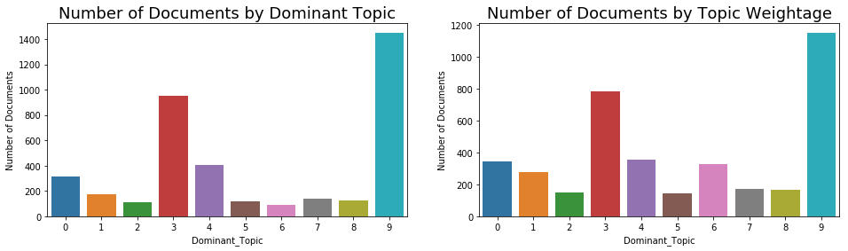

```python
# Documents counts by dominant topics

f, (ax1, ax2) = plt.subplots(1, 2, figsize=(16, 4))
sns.barplot(x='Dominant_Topic', y='count', data=df_dominant_topic_in_each_doc,ax=ax1)
ax1.set_title('Number of Documents by Dominant Topic', fontsize=18)
ax1.set(ylabel='Number of Documents')

ax2=sns.barplot(x='index', y='count', data=df_topic_weightage_by_doc,ax=ax2)
ax2.set_title('Number of Documents by Topic Weightage', fontsize=18)
ax2.set(ylabel='Number of Documents')
ax2.set(xlabel='Dominant_Topic')

plt.show()
figure = ax1.get_figure()
figure.savefig('image/numberof_documnetsby_topics.png',bbox_inches = 'tight')
```

```python
# Get topic weights and dominant topics ------------
from sklearn.manifold import TSNE
from bokeh.plotting import figure, output_file, show
from bokeh.models import Label
from bokeh.io import output_notebook

# Get topic weights
topic_weights = []
for i, row_list in enumerate(lda_model[bow_corpus]):
    topic_weights.append([w for i, w in row_list[0]])

# Array of topic weights
arr = pd.DataFrame(topic_weights).fillna(0).values

# Keep the well separated points (optional)
arr = arr[np.amax(arr, axis=1) > 0.35]

# Dominant topic number in each doc
topic_num = np.argmax(arr, axis=1)

# tSNE Dimension Reduction
tsne_model = TSNE(n_components=2, verbose=1, random_state=0, angle=.99, init='pca')
tsne_lda = tsne_model.fit_transform(arr)

# Plot the Topic Clusters using Bokeh
output_notebook()
n_topics = 10
mycolors = np.array([color for name, color in mcolors.TABLEAU_COLORS.items()])
plot = figure(title="t-SNE Clustering of {} LDA Topics".format(n_topics),
              plot_width=700, plot_height=400)
plot.scatter(x=tsne_lda[:,0], y=tsne_lda[:,1], color=mycolors[topic_num])
show(plot)
```

```
[t-SNE] Computing 91 nearest neighbors...
[t-SNE] Indexed 3274 samples in 0.008s...
[t-SNE] Computed neighbors for 3274 samples in 0.350s...
[t-SNE] Computed conditional probabilities for sample 1000 / 3274
[t-SNE] Computed conditional probabilities for sample 2000 / 3274
[t-SNE] Computed conditional probabilities for sample 3000 / 3274
[t-SNE] Computed conditional probabilities for sample 3274 / 3274
[t-SNE] Mean sigma: 0.081014
[t-SNE] KL divergence after 250 iterations with early exaggeration: 67.962662
[t-SNE] Error after 1000 iterations: 0.895189
```

[interactive chart not shown]